# Trabajo Final - Métodos Estadísticos Avanzados en Ciencia de los Datos

```r
r2_model_test<-r2_score(preds, data_test_z$Costo.de.ventas_dif)
adj_r2_model_test<-adj_r2_score(preds, data_test_z$Costo.de.ventas_dif)
mse_test = mean((data_test_z$Costo.de.ventas_dif - preds)^2)

print(r2_model_test)
```

```
## [1] 0
```

```r
print(adj_r2_model_test)
```

```
## [1] 0
```

```r
print(mse_test)
```

```
## [1] 1.291249
```

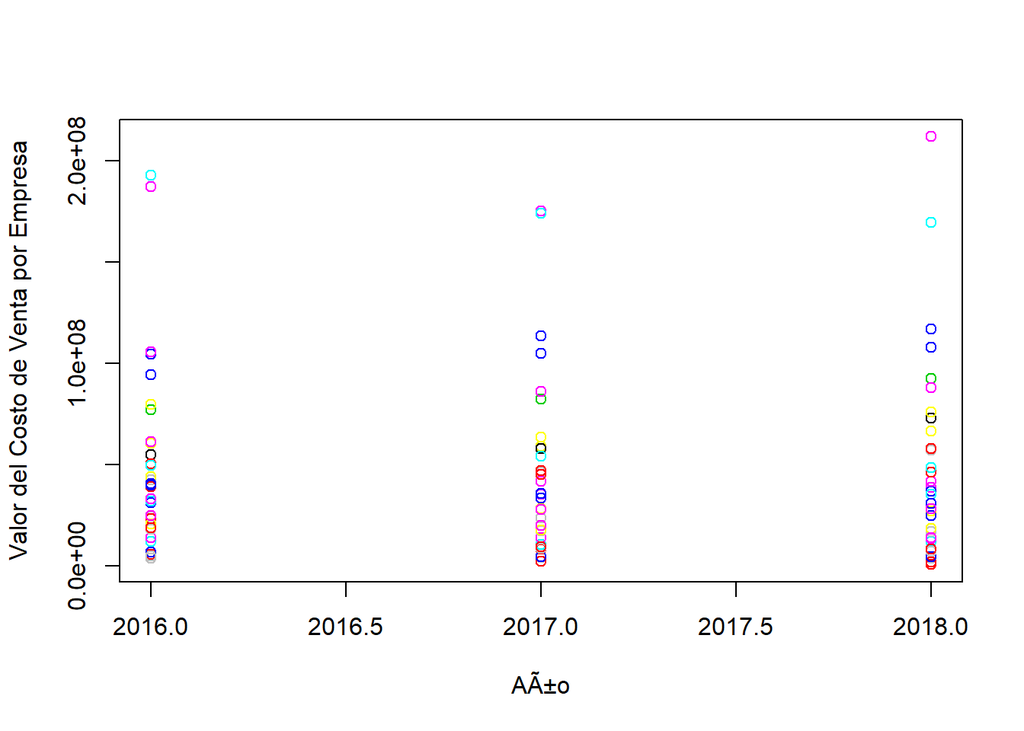

```r
plot(all_data$Year, all_data$Costo.de.ventas, col=all_data$NIT, xlab = "AÃ±o", ylab = "Valor del Costo de Venta por Empresa")
```

```r
## Generalized linear model Lasso quitando empresa outlier
data_train_z_sinoutl = data_train_z[-c(12, 34, 56), ]
glm_obj_s <- glmmLasso(Costo.de.ventas_dif~TRM+PIB+Balance_CC+Desempleo+Balance_Fiscal, rnd = list(NIT=~1+PIB), data = data_train_z_sinoutl, lambda=5, family = gaussian(link ="identity"))
summary(glm_obj_s)
```

```
## Call:
## glmmLasso(fix = Costo.de.ventas_dif ~ TRM + PIB + Balance_CC +
##     Desempleo + Balance_Fiscal, rnd = list(NIT = ~1 + PIB), data = data_train_z_sinoutl,
##     lambda = 5, family = gaussian(link = "identity"))
##
##
## Fixed Effects:
##
## Coefficients:
##                  Estimate StdErr z.value p.value
## (Intercept)    -0.0019545     NA      NA      NA
## TRM             0.0505839     NA      NA      NA
## PIB             0.0000000     NA      NA      NA
## Balance_CC      0.0355940     NA      NA      NA
## Desempleo      -0.0072382     NA      NA      NA
## Balance_Fiscal  0.0094652     NA      NA      NA
##
## Random Effects:
##
## StdDev:
##                NIT    NIT:PIB
## NIT     0.01474609 0.00955623
## NIT:PIB 0.00955623 0.05639679
```

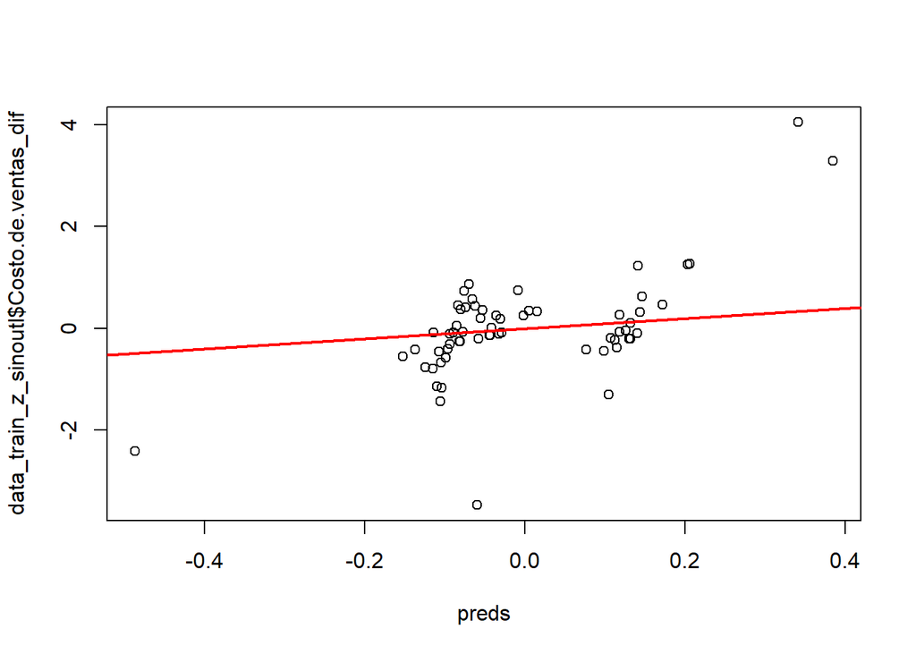

```r
preds = predict(glm_obj_s, data = data_train_z_sinoutl)
plot(preds,data_train_z_sinoutl$Costo.de.ventas_dif)
abline(a=0, b=1, lwd = 2, col = 'red')
```

Aplicando la remoción de outliers la distribución hacia el centro de los datos se extiende más y esto es deseado, y la escala no se ve demasiado afectada por la corrección. En términos de mercado esta clase de resultados es la más natural y razonable entre todas, donde es claro como los indicadores macro-economicos pueden afectar de manera diferente a cada componente que representa la industria.

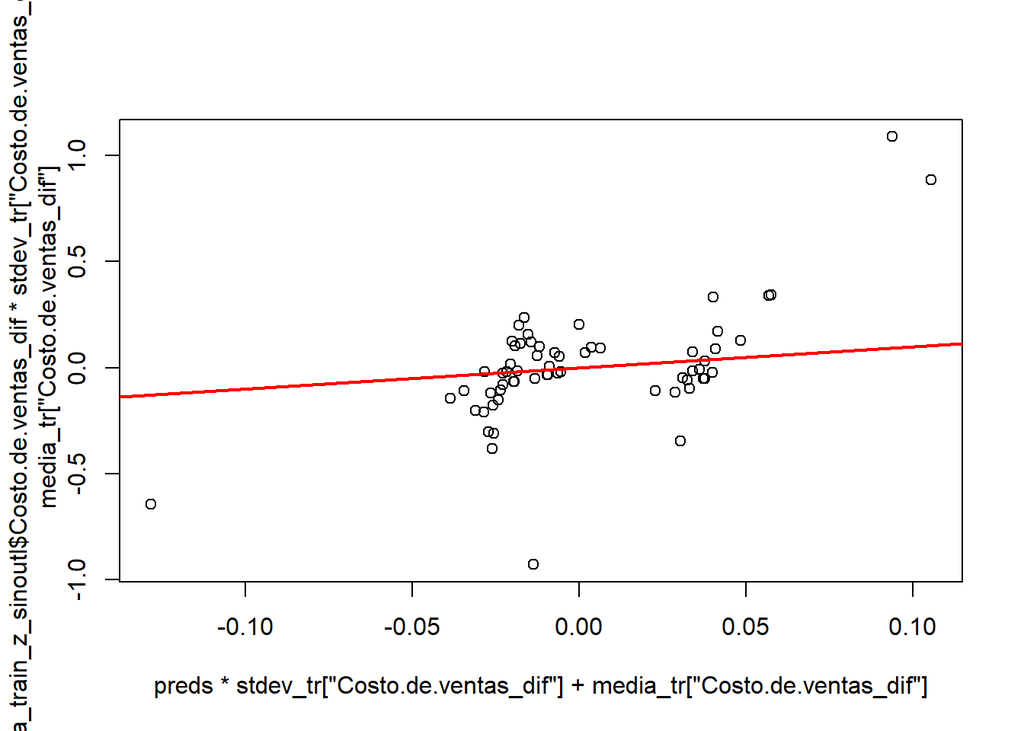

```r
plot(preds*stdev_tr['Costo.de.ventas_dif']+media_tr['Costo.de.ventas_dif'],
     data_train_z_sinoutl$Costo.de.ventas_dif*stdev_tr['Costo.de.ventas_dif']+media_tr['Costo.de.ventas_dif'])
abline(a=0, b=1, lwd = 2, col = 'red')
```

```r
r2_model_train_sinoutl<-r2_score(preds, data_train_z_sinoutl$Costo.de.ventas_dif)
adj_r2_model_train_sinoutl<-adj_r2_score(preds, data_train_z_sinoutl$Costo.de.ventas_dif)
mse_sinoutl = mean((data_train_z_sinoutl$Costo.de.ventas_dif - preds)^2)

print(r2_model_train_sinoutl)
```

```
## [1] 0.393792
```

```r
print(adj_r2_model_train_sinoutl)
```

```
## [1] 0.3838542
```

```r
print(mse_sinoutl)
```

```
## [1] 0.8680259
```

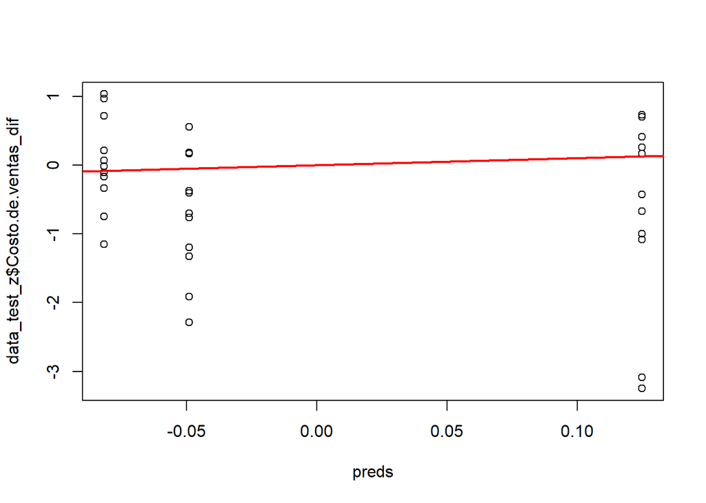

```r
preds = predict(glm_obj_s, newdata = data_test_z)
plot(preds,data_test_z$Costo.de.ventas_dif)
abline(a=0, b=1, lwd = 2, col = 'red')
```

Probando con el conjunto de testeo puede verse en comparación al resultado en test del modelo anterior que la distorsión se evidencia hacia los valores mayores en el conjunto predicho y el sentido de los signos, lo que le reduce razonabilidad. Sobre el efecto de escala éste se esperaba dado el resultado en el set de entrenamiento.

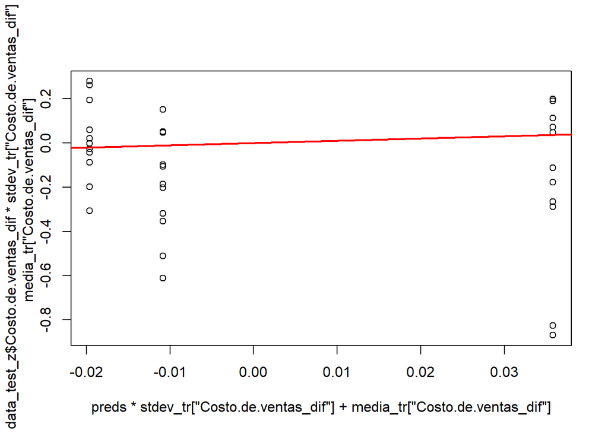

```r
plot(preds*stdev_tr['Costo.de.ventas_dif']+media_tr['Costo.de.ventas_dif'],
     data_test_z$Costo.de.ventas_dif*stdev_tr['Costo.de.ventas_dif']+media_tr['Costo.de.ventas_dif'])
abline(a=0, b=1, lwd = 2, col = 'red')
```

```r
r2_model_test_sinoutl<-r2_score(preds, data_test_z$Costo.de.ventas_dif)
adj_r2_model_test_sinoutl<-adj_r2_score(preds, data_test_z$Costo.de.ventas_dif)
mse_sinoutl_test = mean((data_test_z$Costo.de.ventas_dif - preds)^2)

print(r2_model_test_sinoutl)
```

```
## [1] 0.03421528
```

```r
print(adj_r2_model_test_sinoutl)
```

```
## [1] 0.003060938
```

```r
print(mse_sinoutl_test)
```

```
## [1] 1.332652
```

```r
## Trasnformacion de variables (productos y divisiones)
vars = c("TRM","PIB","Desempleo","Inflacion","Tasa_Intervencion","Balance_CC","Balance_Fiscal")
df = data_train_z[vars]
# x^2
df_p <- df^2
vector = c()
for (i in colnames(df)) vector <- c(vector, paste(i,'_p_',i, sep  = ''))
colnames(df_p) <-  vector
# xi*xj
df_s <- do.call(cbind,combn(colnames(df), 2,
               FUN= function(x) list(df[x[1]]*df[x[2]])))
colnames(df_s) <-  combn(colnames(df), 2,
                 FUN = paste, collapse="_p_")
# xi/xj
df_t <- do.call(cbind,combn(colnames(df), 2,
               FUN= function(x) list(df[x[1]]/df[x[2]])))
colnames(df_t) <-  combn(colnames(df), 2,
                 FUN = paste, collapse="_d_")
df_trans=cbind(data_train_z,df_p,df_s,df_t)
```

```r
## Generalized linear model Lasso con todas las transformaciones
glm_obj <- glmmLasso(Costo.de.ventas_dif~TRM+PIB+Desempleo+Inflacion+Tasa_Intervencion+Balance_CC+Balance_Fiscal+TRM_p_TRM+PIB_p_PIB+Desempleo_p_Desempleo+Inflacion_p_Inflacion+Tasa_Intervencion_p_Tasa_Intervencion+Balance_CC_p_Balance_CC+Balance_Fiscal_p_Balance_Fiscal+TRM_p_PIB+TRM_p_Desempleo+TRM_p_Inflacion+TRM_p_Tasa_Intervencion+TRM_p_Balance_CC+TRM_p_Balance_Fiscal+PIB_p_Desempleo+PIB_p_Inflacion+PIB_p_Tasa_Intervencion+PIB_p_Balance_CC+PIB_p_Balance_Fiscal+Desempleo_p_Inflacion+Desempleo_p_Tasa_Intervencion+Desempleo_p_Balance_CC+Desempleo_p_Balance_Fiscal+Inflacion_p_Tasa_Intervencion+Inflacion_p_Balance_CC+Inflacion_p_Balance_Fiscal+Tasa_Intervencion_p_Balance_CC+Tasa_Intervencion_p_Balance_Fiscal+Balance_CC_p_Balance_Fiscal+TRM_d_PIB+TRM_d_Desempleo+TRM_d_Inflacion+TRM_d_Tasa_Intervencion+TRM_d_Balance_CC+TRM_d_Balance_Fiscal+PIB_d_Desempleo+PIB_d_Inflacion+PIB_d_Tasa_Intervencion+PIB_d_Balance_CC+PIB_d_Balance_Fiscal+Desempleo_d_Inflacion+Desempleo_d_Tasa_Intervencion+Desempleo_d_Balance_CC+Desempleo_d_Balance_Fiscal+Inflacion_d_Tasa_Intervencion+Inflacion_d_Balance_CC+Inflacion_d_Balance_Fiscal+Tasa_Intervencion_d_Balance_CC+Tasa_Intervencion_d_Balance_Fiscal+Balance_CC_d_Balance_Fiscal, rnd = list(NIT=~1+PIB+Balance_CC), data = df_trans, lambda=15, family = gaussian(link ="identity"))
summary(glm_obj)
```

```
## Call:
## glmmLasso(fix = Costo.de.ventas_dif ~ TRM + PIB + Desempleo +
##     Inflacion + Tasa_Intervencion + Balance_CC + Balance_Fiscal +
##     TRM_p_TRM + PIB_p_PIB + Desempleo_p_Desempleo + Inflacion_p_Inflacion +
##     Tasa_Intervencion_p_Tasa_Intervencion + Balance_CC_p_Balance_CC +
##     Balance_Fiscal_p_Balance_Fiscal + TRM_p_PIB + TRM_p_Desempleo +
##     TRM_p_Inflacion + TRM_p_Tasa_Intervencion + TRM_p_Balance_CC +
##     TRM_p_Balance_Fiscal + PIB_p_Desempleo + PIB_p_Inflacion +
##     PIB_p_Tasa_Intervencion + PIB_p_Balance_CC + PIB_p_Balance_Fiscal +
##     Desempleo_p_Inflacion + Desempleo_p_Tasa_Intervencion + Desempleo_p_Balance_CC +
##     Desempleo_p_Balance_Fiscal + Inflacion_p_Tasa_Intervencion +
##     Inflacion_p_Balance_CC + Inflacion_p_Balance_Fiscal + Tasa_Intervencion_p_Balance_CC +
##     Tasa_Intervencion_p_Balance_Fiscal + Balance_CC_p_Balance_Fiscal +
##     TRM_d_PIB + TRM_d_Desempleo + TRM_d_Inflacion + TRM_d_Tasa_Intervencion +
##     TRM_d_Balance_CC + TRM_d_Balance_Fiscal + PIB_d_Desempleo +
##     PIB_d_Inflacion + PIB_d_Tasa_Intervencion + PIB_d_Balance_CC +
##     PIB_d_Balance_Fiscal + Desempleo_d_Inflacion + Desempleo_d_Tasa_Intervencion +
##     Desempleo_d_Balance_CC + Desempleo_d_Balance_Fiscal + Inflacion_d_Tasa_Intervencion +
##     Inflacion_d_Balance_CC + Inflacion_d_Balance_Fiscal + Tasa_Intervencion_d_Balance_CC +
##     Tasa_Intervencion_d_Balance_Fiscal + Balance_CC_d_Balance_Fiscal,
##     rnd = list(NIT = ~1 + PIB + Balance_CC), data = df_trans,
##     lambda = 15, family = gaussian(link = "identity"))
##
##
## Fixed Effects:
##
## Coefficients:
##                                         Estimate StdErr z.value p.value
## (Intercept)                           4.9445e-16     NA      NA      NA
## TRM                                   0.0000e+00     NA      NA      NA
## PIB                                   0.0000e+00     NA      NA      NA
## Desempleo                             0.0000e+00     NA      NA      NA
## Inflacion                             0.0000e+00     NA      NA      NA
## Tasa_Intervencion                     0.0000e+00     NA      NA      NA
## Balance_CC                            0.0000e+00     NA      NA      NA
## Balance_Fiscal                        0.0000e+00     NA      NA      NA
## TRM_p_TRM                             0.0000e+00     NA      NA      NA
## PIB_p_PIB                             0.0000e+00     NA      NA      NA
## Desempleo_p_Desempleo                 0.0000e+00     NA      NA      NA
## Inflacion_p_Inflacion                 0.0000e+00     NA      NA      NA
```

[output cut: 38 more lines]

```
## Desempleo_d_Balance_Fiscal            0.0000e+00     NA      NA      NA
## Inflacion_d_Tasa_Intervencion         0.0000e+00     NA      NA      NA
## Inflacion_d_Balance_CC                0.0000e+00     NA      NA      NA
## Inflacion_d_Balance_Fiscal            0.0000e+00     NA      NA      NA
## Tasa_Intervencion_d_Balance_CC        0.0000e+00     NA      NA      NA
## Tasa_Intervencion_d_Balance_Fiscal    0.0000e+00     NA      NA      NA
## Balance_CC_d_Balance_Fiscal           0.0000e+00     NA      NA      NA
##
## Random Effects:
##
## StdDev:
##                       NIT    NIT:PIB NIT:Balance_CC
## NIT            0.24982101 0.08081845     0.05548218
## NIT:PIB        0.08081845 0.60324781     0.27684708
## NIT:Balance_CC 0.05548218 0.27684708     0.56751550
```

```r
### Para que converja, toca poner un lamba alto. Esto conlleva a que todas las betas sean 0
### Un lambda menor lleva a que la matriz no sea invertible
```